# Represión Estatal

2023-07-12

```r
library(rio)

d1 = "https://docs.google.com/spreadsheets/d/e/2PACX-1vSxZIpRqxr3-WT10cyRRtqxbZW0d_KRfC7ch6OPJNM_S4WzaNuKT4J2ONq67WjfiLQWIFBroxjAwZGY/pub?output=csv"
data = read.csv(d1)
```

# Objetivo del analisis:

El objetivo de este análisis cuantitativo es examinar la relación entre la represión estatal en el mundo y las variables independientes: inversión extranjera directa (IED), exclusión por índice de localización urbano rural, nivel de institucionalización de los partidos políticos, índice de paz positiva, cercanía a Occidente, corrupción, grado de libertad de prensa, nivel de desigualdad económica, nivel de ingresos, índice de desarrollo humano, libertad económica y estado de derecho. El estudio tiene como finalidad identificar las posibles influencias de estas variables en la represión estatal y comprender su interacción con el fenómeno.

Mediante un enfoque de análisis cuantitativo, se recopilarán datos de una amplia muestra de países y se utilizarán técnicas estadísticas, como análisis de regresión, para examinar las relaciones entre la represión estatal y las variables independientes mencionadas.Y analisis de congloemrados que permitira agrupar las variables en base a su similitud. El objetivo principal es determinar si existe una asociación significativa entre la represión estatal y estas variables, y en qué medida cada una de ellas puede explicar la variabilidad en los niveles de represión observados.

Al obtener resultados significativos, se espera proporcionar una comprensión más profunda de los factores que contribuyen a la represión estatal en el mundo. Esto permitirá informar y respaldar la formulación de políticas y estrategias destinadas a reducir la represión estatal y promover la protección de los derechos humanos a nivel global. Además, este análisis contribuirá al cuerpo de conocimientos existente sobre la relación entre la represión estatal y las variables socioeconómicas y políticas.

# Construccion de bases de datos

La bases de datos La variable dependiente es el nivel de represión estatal en el mundo, recuperado del Índice de violencia física de la base de datos de V-dem . Tenemos 12 variable independientes relevantes para explicar el comportamiento de la variable dependiente.

V1. Inversión Extranjera directa (IED). V2. Exclusión por índice de localización urbano rural V3. Nivel de institucionalización de los partidos políticos V4. Índice de paz positiva V5. Cercanía a Occidente V6 :Corrupción V7: Grado de libertad de prensa V8: Nivel de desigualdad económica V9: Nivel de ingresos V10:Índice de desarrollo humano V11: Libertad Económica V12: Estado de Derecho

Para el proceso de creacion de base de datos, en orimer lugar, se recopilaros las bases de datos y estadisticas. En segundo lugar, de forma individual, trabajamos las tres variables independientes junto a la varibale dependiente. Limpiamos la data disponible, juntamos las variables en un data frame y, por ultimo hicimos, de la base de datos creada con la base de datos de la variable dependiente. El proceso de merge consisitió en cambiar el nombre de las columnas, seleccionar las columnas relevantes a traves del uso de codigos de limpieza y de dplyr, con el fin de perder la menor cantidad de casos. Por ultimo el merge permitio que unifiquemos la bases de datos creadas de forma individual.

# Regresiones

Regresion: modelo 1

|  | Modelo 1 |
| --- | --- |
| (Intercept) | 914.000 |
|  | (606.012) |
| fdi-1,71E+12 | 27.000 |
|  | (857.030) |
| fdi-12372192 | −15.000 |
|  | (857.030) |
| fdi-2,64E+12 | −7.000 |
|  | (857.030) |
| fdi-272335307 | −40.000 |
|  | (857.030) |
| fdi-3,34E+13 | 23.000 |
|  | (857.030) |
| fdi-4,36E+12 | −307.000 |
|  | (857.030) |
| fdi-79957355 | 10.000 |
|  | (857.030) |
| fdi1,23E+14 | −688.000 |
|  | (857.030) |
| fdi1,42E+14 | −400.000 |
|  | (857.030) |
| fdi1,47E+14 | 60.000 |
|  | (857.030) |
| fdi1,53E+14 | −17.000 |
|  | (857.030) |
| fdi1,86E+14 | −8.000 |
|  | (857.030) |
| fdi1,89E+14 | −25.000 |
|  | (857.030) |
| fdi1071913716 | −527.000 |
|  | (857.030) |

[output cut: 187 more lines]

+ p < 0.1, * p < 0.05, ** p < 0.01, *** p < 0.001

El modelo salió significativo, pero con un R2 de 0.3798; esto significa que el 37.98% de la variabilidad de la variable dependiente puede ser explicada por las variables independientes empleadas.

Vemos que la variable con mayor significancia es exclusión por índice de Localización Urbano-Rural (v2xpe_exlgeo).

Esto se interpreta como: A mayor nivel de exclusión en el índice de Localización Urbano-Rural, el respeto a la integridad física por parte del Estado se reduce en -5.159e-01.

Por otro lado, vemos que mientras más institucionalizado se encuentren los partidos de un país, habrá más respeto por la integridad física de los ciudadanos de parte del Estado. Sin embargo, esto se da con una significancia al 0.01.

Juzgo que vale la pena estabelcer la correlación entre la variable dependiente y la exclusión or índice de localización Urbano-Rural.

# Análisis factorial exploratorio:

Realizamos esta técnica porque no contamos con una teoría previa contundente. Queremos explorar la relación entre las distitnas variables que aportaron los miembros del grupo y si es que estas formarían parte de un concepto que ayude explicar el fenómeno expresado en nuestra variable independiente.

### Arreglamos algunos nombres de la data

## 1. subseteamos:

excluimos las que no pueden entrar en el análisis.

omitimos los casos perdidos (aqui perdemos mucha data porque algunas varaibles tienen muchos NAs)

## 2. Calculamos la matriz de correlación

antes nos vamos a asegurar que las variables sean leidas con el tipo numérico.

```
##  num [1:46] 931 573 607 957 977 849 789 844 856 826 ...
```

```
##  num [1:46] 2.93 3.39 3.84 1.39 1.57 ...
```

```
##  num [1:46] 574 339 429 893 948 468 593 716 673 709 ...
```

```
##  num [1:46] 193 392 734 34 0.07 414 233 268 239 144 ...
```

```
##  num [1:46] 54.5 32.3 21.8 37.3 26.5 12.7 38.5 41.4 24.3 22.1 ...
```

```
##  num [1:46] 58.8 65.9 69.4 71 71.2 ...
```

```
##  num [1:46] 0.49 0.49 0.43 0.8 0.39 0.59 0.49 0.55 0.49 0.31 ...
```

```
##  num [1:46] 66.5 46.2 50.6 72 55.6 69.5 51.9 69 59.4 57.8 ...
```

```
##  num [1:46] 796 745 586 916 661 693 754 795 449 593 ...
```

convertimos las que no.

confirmamos:

```
##  num [1:46] 574 339 429 893 948 468 593 716 673 709 ...
```

```
##  num [1:46] 54.5 32.3 21.8 37.3 26.5 12.7 38.5 41.4 24.3 22.1 ...
```

```
##  num [1:46] 58.8 65.9 69.4 71 71.2 ...
```

Ahora sí, calculamos la matriz de correlaciones.

```r
library(polycor)
corMatrix=polycor::hetcor(theData)$correlations #se hace con esa nueva data "theData" y le pone al objeto "corMatrix"
```

## 3. Exploramos las correlaciones:

La Figura muestra las correlaciones entre todas las variables a utilizar:

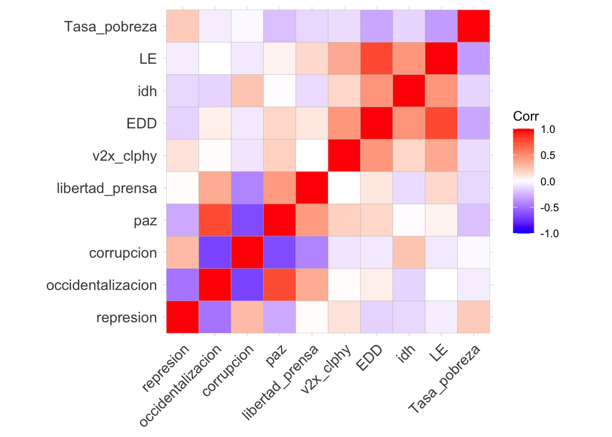

El gráfico ya nos advierte que puede que se ha encontrado una posible correlación entre las variables que vamos a utilizar, esto porque se ha formado un bloque, aunque no de color rojizo uniforme.

## 5. Verificar si la matriz de correlaciones es adecuada

(queremos las dos apunten FALSE)

Hnula, La matriz de correlacion es una matriz identidad:

```
## [1] FALSE
```

Esto significa que no se trata de una matriz donde las variables solo están relacionadas consigo mismas

Hnula: La matriz de correlacion es una matriz singular,

```
## [1] FALSE
```

Esto nos indica que la matriz puede invertirse

Ambas pruebas señalan que puede continuarse con el análisis.

## 6. Determinamos en cuantos factores o variables latentes podríamos redimensionar la data: En este caso, la función fa.parallel nos dará la sugerencia:

```
## Parallel analysis suggests that the number of factors =  2  and the number of components =  NA
```

r nos hace un advertencia sobre la probabilidad de error, nos señala que los pesos estimados para las puntuaciones de los factores probablemente sean incorrectos. Nos sugiere probar con otro método de estimación de la puntuación de los factores.

## 2. Redimensionar a número menor de factores

Resultado inicial:

para ello creamos un objeto llamado “resfa”:

```
##
## Loadings:
##                   MR1
## represion         -0.393
## occidentalizacion  0.845
## corrupcion        -0.747
## paz                0.868
## libertad_prensa    0.460
## v2x_clphy          0.163
## EDD                0.262
## idh
## LE                 0.206
## Tasa_pobreza      -0.211
##
##                  MR1
## SS loadings    2.576
## Proportion Var 0.258
```

Es la unica tabla que podemos pedir.

graficamos

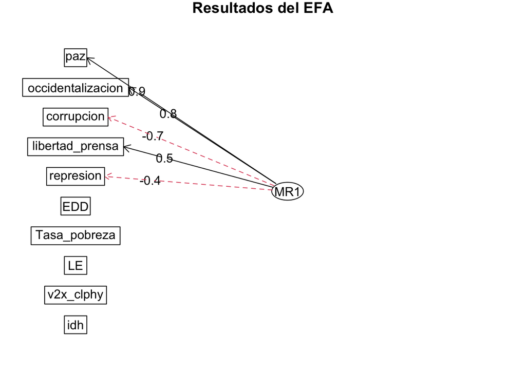

El análisis solo puede llegar hasta aqui, se han agrupado algunas variables en un solo factor (algunas con indices negativos). pero esta relación en realidad no nos dice mucho.

# Análisis de conglomerados:

el anterior análisis no aportó mucho a nuestra exploración de los datos. si bien antes trabajamos con variables, ahora trabajaremos con los casos.

Vamos a recodificar esta variable para que pueda leerse como numérica:

listo

```r
DinaAsesina$Tasa_pobreza<- as.numeric(DinaAsesina$Tasa_pobreza)
DinaAsesina$libertad_prensa<- as.numeric(DinaAsesina$libertad_prensa)
```

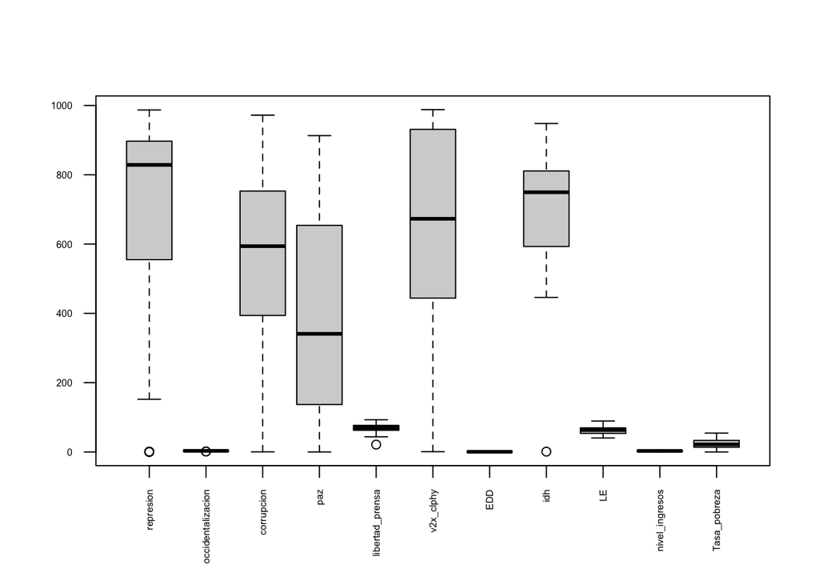

cambiamos el rango para poder leer

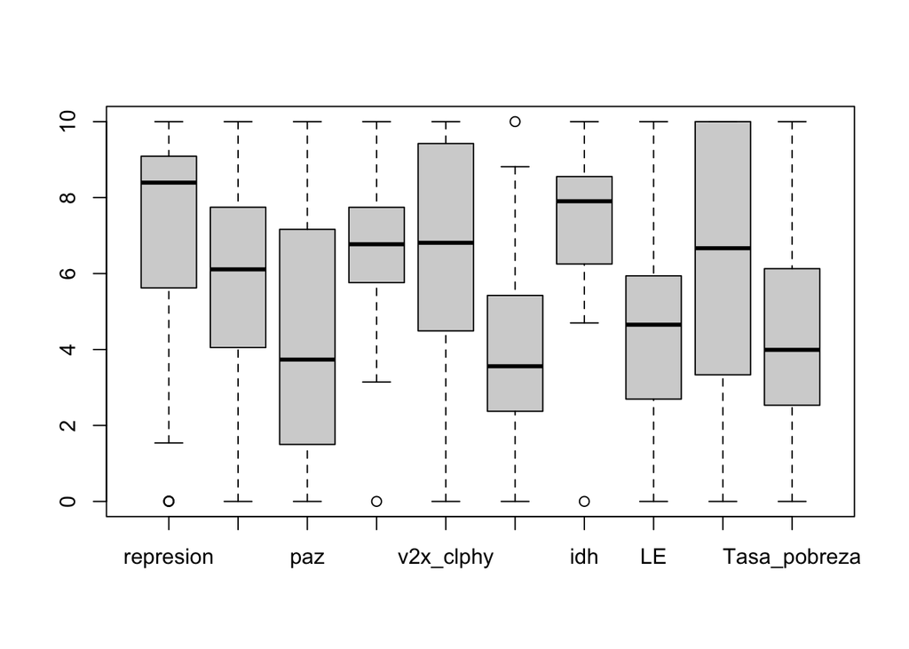

tipificamos:

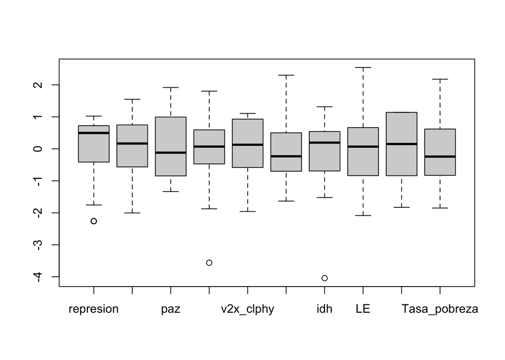

correlacion:

```
##                   represion  corrupcion          paz libertad_prensa
## represion        1.00000000  0.29167770 -0.287701256     0.011102140
## corrupcion       0.29167770  1.00000000 -0.654887061    -0.434200802
## paz             -0.28770126 -0.65488706  1.000000000     0.431974149
## libertad_prensa  0.01110214 -0.43420080  0.431974149     1.000000000
## v2x_clphy        0.11819317 -0.08628455  0.196350805    -0.002293092
## EDD             -0.14788587 -0.07391465  0.166995658     0.100928998
## idh             -0.13438180  0.25411927 -0.005968637    -0.118523720
## LE              -0.05885017 -0.06749707  0.051105281     0.160528431
## nivel_ingresos  -0.09991216 -0.09168747  0.172542103     0.431325417
## Tasa_pobreza     0.22131896 -0.02266047 -0.214289283    -0.129586470
##                    v2x_clphy         EDD          idh          LE
## represion        0.118193171 -0.14788587 -0.134381795 -0.05885017
## corrupcion      -0.086284549 -0.07391465  0.254119267 -0.06749707
## paz              0.196350805  0.16699566 -0.005968637  0.05110528
## libertad_prensa -0.002293092  0.10092900 -0.118523720  0.16052843
## v2x_clphy        1.000000000  0.44913142  0.170464626  0.36890855
## EDD              0.449131422  1.00000000  0.460160258  0.77907875
## idh              0.170464626  0.46016026  1.000000000  0.45070867
## LE               0.368908549  0.77907875  0.450708672  1.00000000
## nivel_ingresos   0.271783209  0.25601998  0.027010253  0.36506360
## Tasa_pobreza    -0.111363407 -0.30496790 -0.139708923 -0.33953625
##                 nivel_ingresos Tasa_pobreza
## represion          -0.09991216   0.22131896
## corrupcion         -0.09168747  -0.02266047
## paz                 0.17254210  -0.21428928
## libertad_prensa     0.43132542  -0.12958647
## v2x_clphy           0.27178321  -0.11136341
## EDD                 0.25601998  -0.30496790
## idh                 0.02701025  -0.13970892
## LE                  0.36506360  -0.33953625
## nivel_ingresos      1.00000000  -0.67598548
## Tasa_pobreza       -0.67598548   1.00000000
```

calculo de matriz de distancias:

Estrategia de particion:

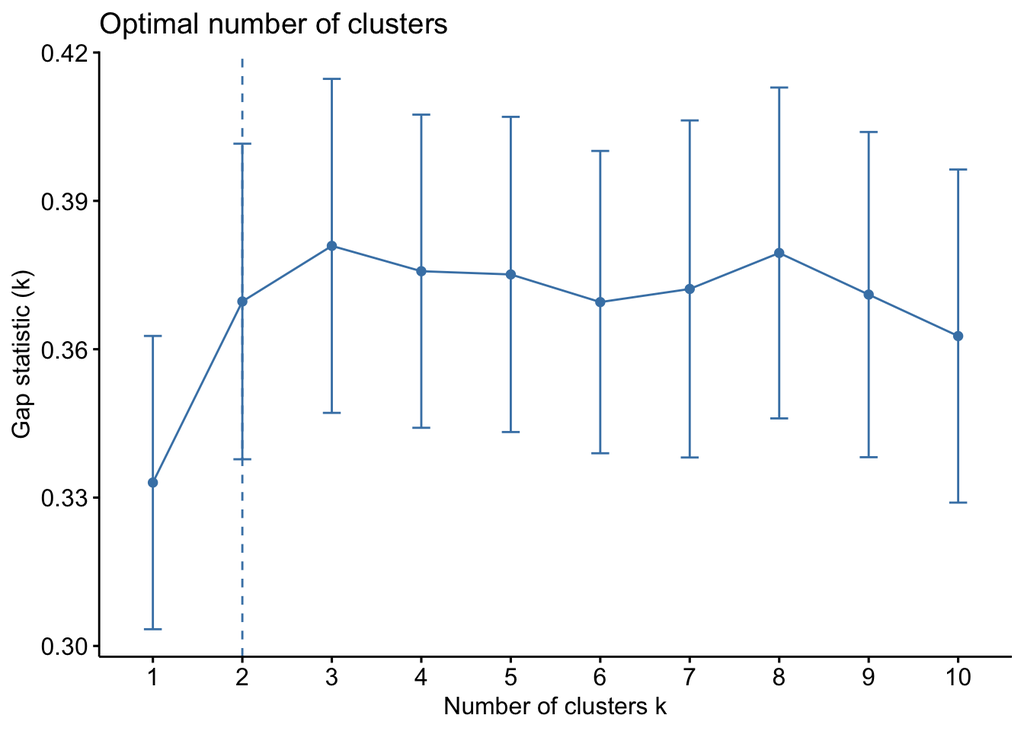

Nos dice que el número óptimo de clusters es 2. Es decir, los países pueden agruparse, según la información que hemos proporcionado al análisis, en dos grandes grupos.

|  | represion | corrupcion | paz | libertad_prensa | v2x_clphy | EDD | idh | LE | nivel_ingresos | Tasa_pobreza | pam |
| --- | --- | --- | --- | --- | --- | --- | --- | --- | --- | --- | --- |
| Albania | 0.8371086 | 0.0935322 | -0.6472589 | -0.7544350 | 0.9289860 | -0.4335796 | 0.4565672 | 0.3810257 | -1.8289276 | 2.1783791 | 1 |
| Algeria | -0.3542847 | -0.7655895 | 0.0616276 | -0.2213438 | -0.1826901 | -0.4335796 | 0.1680202 | -1.5360100 | -0.8391550 | 0.5374846 | 1 |
| Angola | -0.2411356 | -0.4365642 | 1.2799149 | 0.0380988 | -0.0771119 | -0.8338070 | -0.7315675 | -1.1204949 | 0.1506176 | -0.2386142 | 2 |
| Australia | 0.9236344 | 1.2597443 | -1.2136556 | 0.1577266 | 1.0718271 | 1.6342617 | 1.1355013 | 0.9004196 | 0.1506176 | 0.9070554 | 1 |
| Austria | 0.9901927 | 1.4608153 | -1.3345225 | 0.1696894 | -1.2602085 | -1.1006252 | -0.3072337 | -0.6483186 | 0.1506176 | 0.1087824 | 1 |
| Benin | 0.5642196 | -0.2939865 | 0.1399969 | 1.4512015 | 0.6029358 | 0.2334660 | -0.1261846 | 0.6643315 | 1.1403902 | -0.9112332 | 2 |
| Bhutan | 0.3645448 | 0.1629931 | -0.5047691 | -0.5293853 | -0.6733181 | -0.4335796 | 0.2189403 | -0.9977290 | -0.8391550 | 0.9957524 | 1 |
| Bolivia | 0.5475801 | 0.6126611 | -0.3800906 | 0.5928725 | -1.9591981 | -0.0333523 | 0.4509094 | 0.6171139 | -1.8289276 | 1.2101035 | 1 |
| Bosnia and Herzegovina | 0.5875150 | 0.4554601 | -0.4833957 | -1.3914527 | 0.5128838 | -0.4335796 | -1.5066839 | -0.2894646 | -0.8391550 | -0.0538288 | 1 |
| Botswana | 0.4876776 | 0.5870702 | -0.8218088 | -0.4628423 | -0.9558949 | -1.6342617 | -0.6919630 | -0.4405610 | 0.1506176 | -0.2164400 | 1 |
| Cameroon | -0.6604528 | -2.0032001 | 1.6040790 | -0.3267658 | 1.0407747 | 0.8338070 | 0.5301184 | 0.2677034 | -0.8391550 | 0.8405327 | 2 |
| Chad | -2.2606803 | -0.7070961 | 1.9175565 | 0.1674463 | -1.9589808 | 2.3013073 | 1.3165504 | 1.3442654 | -0.8391550 | -1.2438469 | 2 |
| Croatia | 0.8304528 | 0.7333037 | -0.8467445 | 0.2399707 | -0.5832661 | -1.1006252 | -1.2294525 | -0.8371891 | 1.1403902 | -1.0516701 | 1 |
| Cyprus | -2.2579514 | 1.1208224 | -0.9607363 | -3.5604532 | 0.9476175 | 1.1673298 | 1.0619501 | 0.1260505 | 0.1506176 | -1.8499431 | 1 |
| Dominican Republic | 0.7239595 | 0.2470774 | 1.2692281 | -0.9450917 | 0.7861450 | 0.3668751 | 0.9714256 | -0.4500045 | 0.1506176 | 1.0548837 | 1 |

Con las siluetas podemso percatarnos de la cantidad de países mal clausetrizados, en general las barras no son tan altas y esto nos hace dudar de la clausterización en alguna medida.

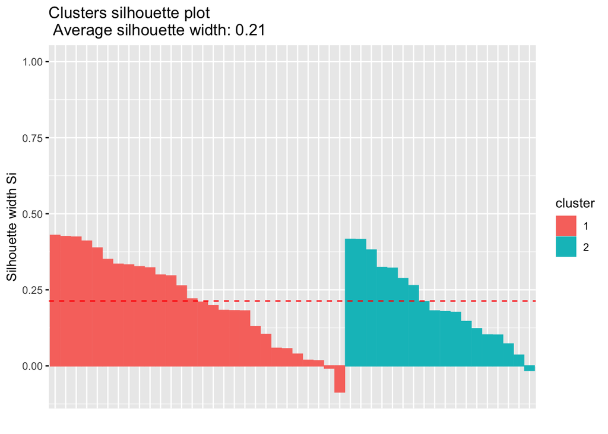

```
## [1] "Angola" "Cyprus" "Iraq"
```

```
##                               [,1]         [,2]
## Albania                -0.17437362 -0.123563570
## Algeria                -0.14578189  0.180409342
## Angola                 -0.02918826  0.221348384
## Australia               0.06254310 -0.343831471
## Austria                -0.23751408 -0.121857969
## Benin                   0.19638037 -0.002221127
## Bhutan                 -0.25155629  0.019634667
## Bolivia                -0.20031294 -0.043924248
## Bosnia and Herzegovina -0.16454596 -0.062653063
## Botswana               -0.19654408 -0.050327452
## Cameroon                0.12647968  0.179203525
## Chad                    0.22076400  0.179302884
## Croatia                -0.10267178 -0.066671932
## Cyprus                  0.14331076 -0.265475808
## Dominican Republic      0.02909603 -0.043099094
## East Timor              0.05918514  0.085707054
## El Salvador             0.01265945  0.334770555
## Eswatini                0.16240587  0.238698448
## Ethiopia                0.44102633  0.024400730
## Gabon                   0.34546751 -0.114087570
```

finalmente podemos graficar.

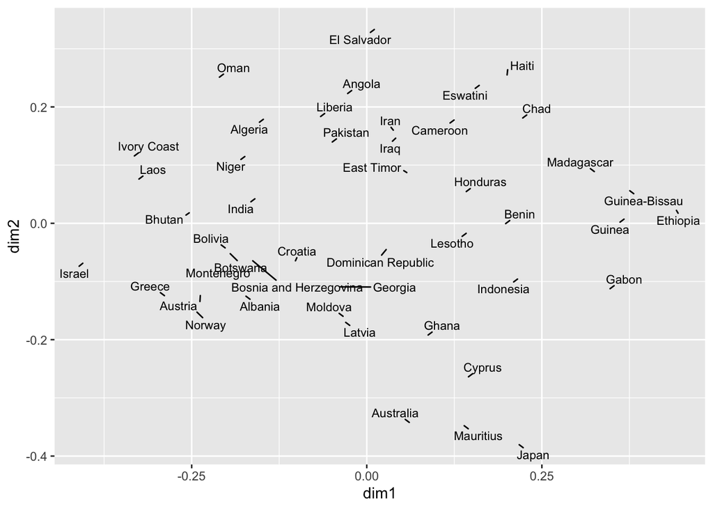

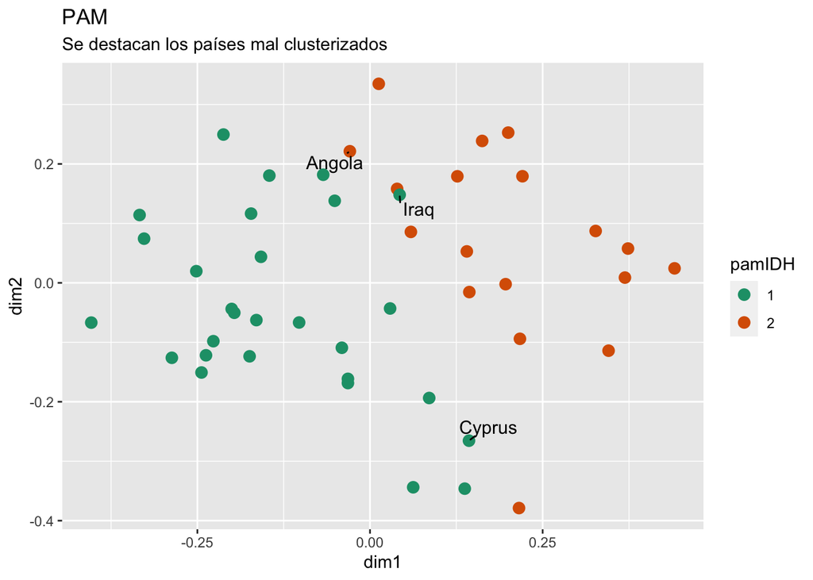

clusterizacion de tipo jerarquico

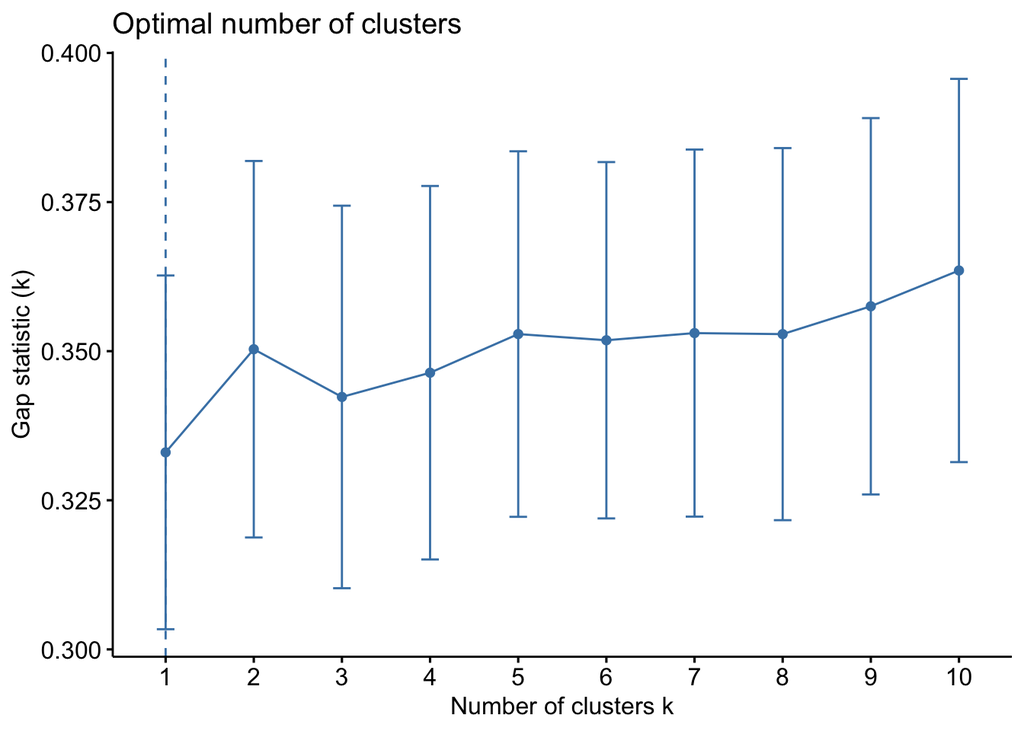

|  | represion | corrupcion | paz | libertad_prensa | v2x_clphy | EDD | idh | LE | nivel_ingresos | Tasa_pobreza | agnes |
| --- | --- | --- | --- | --- | --- | --- | --- | --- | --- | --- | --- |
| Albania | 0.8371086 | 0.0935322 | -0.6472589 | -0.7544350 | 0.9289860 | -0.4335796 | 0.4565672 | 0.3810257 | -1.8289276 | 2.1783791 | 1 |
| Algeria | -0.3542847 | -0.7655895 | 0.0616276 | -0.2213438 | -0.1826901 | -0.4335796 | 0.1680202 | -1.5360100 | -0.8391550 | 0.5374846 | 1 |
| Angola | -0.2411356 | -0.4365642 | 1.2799149 | 0.0380988 | -0.0771119 | -0.8338070 | -0.7315675 | -1.1204949 | 0.1506176 | -0.2386142 | 2 |
| Australia | 0.9236344 | 1.2597443 | -1.2136556 | 0.1577266 | 1.0718271 | 1.6342617 | 1.1355013 | 0.9004196 | 0.1506176 | 0.9070554 | 2 |
| Austria | 0.9901927 | 1.4608153 | -1.3345225 | 0.1696894 | -1.2602085 | -1.1006252 | -0.3072337 | -0.6483186 | 0.1506176 | 0.1087824 | 1 |
| Benin | 0.5642196 | -0.2939865 | 0.1399969 | 1.4512015 | 0.6029358 | 0.2334660 | -0.1261846 | 0.6643315 | 1.1403902 | -0.9112332 | 2 |
| Bhutan | 0.3645448 | 0.1629931 | -0.5047691 | -0.5293853 | -0.6733181 | -0.4335796 | 0.2189403 | -0.9977290 | -0.8391550 | 0.9957524 | 1 |
| Bolivia | 0.5475801 | 0.6126611 | -0.3800906 | 0.5928725 | -1.9591981 | -0.0333523 | 0.4509094 | 0.6171139 | -1.8289276 | 1.2101035 | 1 |
| Bosnia and Herzegovina | 0.5875150 | 0.4554601 | -0.4833957 | -1.3914527 | 0.5128838 | -0.4335796 | -1.5066839 | -0.2894646 | -0.8391550 | -0.0538288 | 1 |
| Botswana | 0.4876776 | 0.5870702 | -0.8218088 | -0.4628423 | -0.9558949 | -1.6342617 | -0.6919630 | -0.4405610 | 0.1506176 | -0.2164400 | 1 |
| Cameroon | -0.6604528 | -2.0032001 | 1.6040790 | -0.3267658 | 1.0407747 | 0.8338070 | 0.5301184 | 0.2677034 | -0.8391550 | 0.8405327 | 2 |
| Chad | -2.2606803 | -0.7070961 | 1.9175565 | 0.1674463 | -1.9589808 | 2.3013073 | 1.3165504 | 1.3442654 | -0.8391550 | -1.2438469 | 2 |
| Croatia | 0.8304528 | 0.7333037 | -0.8467445 | 0.2399707 | -0.5832661 | -1.1006252 | -1.2294525 | -0.8371891 | 1.1403902 | -1.0516701 | 1 |
| Cyprus | -2.2579514 | 1.1208224 | -0.9607363 | -3.5604532 | 0.9476175 | 1.1673298 | 1.0619501 | 0.1260505 | 0.1506176 | -1.8499431 | 2 |
| Dominican Republic | 0.7239595 | 0.2470774 | 1.2692281 | -0.9450917 | 0.7861450 | 0.3668751 | 0.9714256 | -0.4500045 | 0.1506176 | 1.0548837 | 2 |

Visualizamos de mejor

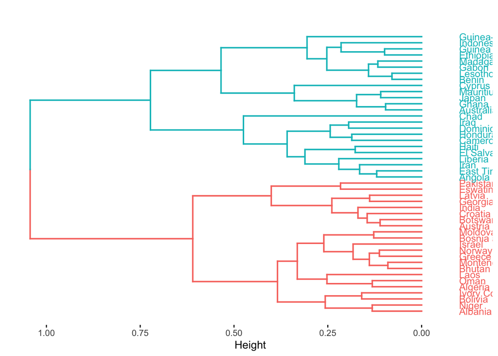

evaluamos el uso de agnes

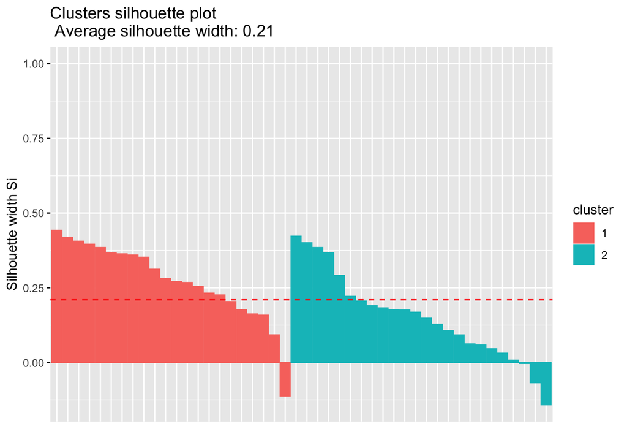

evaluamos los datos (en este caso paises) que estan mal clusterizados

```
## [1] "Angola"   "Eswatini" "Iran"     "Liberia"
```

Exploremos el promedio de cada cluster:

```
##   agnes  represion corrupcion        paz libertad_prensa  v2x_clphy        EDD
## 1     1  0.2467366  0.3389718 -0.5957375      -0.3049133 -0.6019907 -0.6003410
## 2     2 -0.2261752 -0.3107242  0.5460927       0.2795039  0.5518248  0.5503126
##          idh         LE nivel_ingresos Tasa_pobreza
## 1 -0.2874314 -0.5895112     -0.4792377    0.4450918
## 2  0.2634788  0.5403852      0.4393012   -0.4080009
```